# Untitled

Sydney Jansen

2024-03-25

## Introduction

Objective: To investigate vocal plasticity in the tokay gecko (Gekko gecko) by determining if the geckos adjusted the properties of their calls in response to changes in background noise. {the first evidence for vocal plasticity in a reptile}

Methods: The researchers recorded advertisement calls of captive-bred male tokay geckos under different noise conditions and analyzed the duration and amplitude of different call types. 6 males were placed in a sound-chamber with opposing speakers: white noise encapsulating their hearing range and their calls recorded for 4 days. During the recording session, 24 h periods of broadcast noise were alternated with 24 h periods of silence.

Results: Geckos increased the duration of their call syllables in response to noise, but did not adjust the amplitude of their calls. Instead, they produced more high-amplitude syllables and fewer low-amplitude syllables in noise. This demonstrated that the geckos were able to increase the overall signal-to-noise ratio of their calls without using the Lombard effect. In other words, the geckos traded the number of low-amplitude and high-amplitude syllables in each call series to produce more of the louder notes in noise, rather than increasing the amplitude of all components of their call.

#Load packages

[output not shown]

##Load in Data: Raw Data from 6 individuals of treatment, series, type, duration, and amplitude. They did not modify the provided dataset, but R added NAs in duration, so we are removing those.

```
##   animal treatment series type duration amplitude
## 1      1         1      1    2    0.111      72.7
## 2      1         1      1    3    0.422      63.1
## 3      1         1      1    2    0.148      71.1
## 4      1         1      1    3    0.312      64.1
## 5      1         1      1    2    0.111      72.6
## 6      1         1      1    3    0.335      64.7
```

```
## [1] "animal"    "treatment" "series"    "type"      "duration"  "amplitude"
```

[output not shown]

[output cut: 1394 more lines]

### Visualization of Data

Methods: There were not enough graphs and too much information in the “bubble graph”, so I am replicating Figure 2 which shows changes in tokay call parameters in relation to background noise/Grand averages (medians and interquartile ranges) of (a) GECK-note duration. The x axis compares noise to no noise (treatment: noise (1), no noise (0)) and the y axis is the miliseconds of call duration.

Results: There was a slight difference in mean between no noise and noise in relation to call duration. While these results are similar to the original graph, the plot range is different. This is most likely due to me bootstrapping the data instead of doing a LMM or GLMM as stated later in the methods that I will be replicating later.

Figure 2: Grand averages (medians and interquartile ranges) of (a) GECK-note duration with the bars denoting the confidence level.

[figure not shown]

Figure 2 a

Replication:

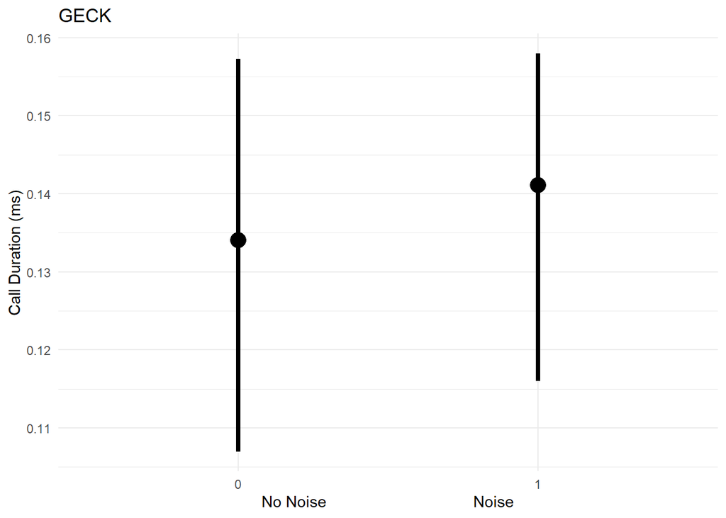

### Statistical Replications/Reanalysis

**Inferential statistical analysis:**

Methods: I plan to replicate a linear mixed models (LMMs) from the *R* package `{lme4}` that was used to investigate the treatment effects (noise vs. no noise) on duration of calls. The individual gecko and the call series were included as random effects to account for the repeated measures design of the experiment. There was no more detailed information about R coding in this regard.

The Chi Square is as reported in the paper: 4.3672 The P value is 0.03663704 which is p < 0.05

Replication: Had to do these to get lmer to work #remove.packages(“Matrix”) #remove.packages(“lme4”) #install.packages(“lme4”, type = “source”) #library(lme4

```
## refitting model(s) with ML (instead of REML)
```

```
## Data: datafig2
## Models:
## null_model: duration ~ (1 | animal) + (1 | series)
## full_model: duration ~ treatment + (1 | animal) + (1 | series)
##            npar     AIC     BIC logLik deviance  Chisq Df Pr(>Chisq)
## null_model    4 -3485.7 -3467.5 1746.8  -3493.7
## full_model    5 -3488.1 -3465.3 1749.0  -3498.1 4.3672  1    0.03664 *
## ---
## Signif. codes:  0 '***' 0.001 '**' 0.01 '*' 0.05 '.' 0.1 ' ' 1
```

```
## [1] 0.03663704
```

###Descriptive statistical analysis:

Methods: Counting Different Call Types and Measuring Their Amplitude: This involves basic descriptive analysis, where the researchers counted the occurrences of different vocalization types and measured their amplitude to describe the vocal behavior of tokay geckos. This is seen in Table S1.Numbers of recorded calls used in the analysis of noise-dependent call regulation (Fig. 2).

Results: While there are 1 or two numbers off by one, the counts were nearly identical to the table.

[figure not shown]

S1

Replication:

```
## # A tibble: 6 × 9
##   animal Number_of_call_series_noise Total_cackles_noise Total_GECKs_noise
##    <int>                       <int>               <int>             <int>
## 1      1                          47                   0               302
## 2      2                           3                   0                18
## 3      3                           3                   0                23
## 4      4                           2                   0                15
## 5      5                           5                   0                32
## 6      6                           1                   0                 9
## # ℹ 5 more variables: Total_Os_noise <int>,
## #   Number_of_call_series_no_noise <int>, Total_cackles_no_noise <int>,
## #   Total_GECKs_no_noise <int>, Total_Os_no_noise <int>
```

### Summary/Discussion

Following their statstical analysis section and decriptors from their tables, I got very close to replicating each section exactly. In the first section, there was not enough information on what they did to the data to explain the difference in scale. I found the mean and bootstrapped, making the graph look very similar. In the second part, it took my awhile to figure out what the X result meant and realized that was chi-square. They did not explain further than them running an LMM, so the data found just running that was not correct until I ran the likelihood ratio test to find the correct chi and p. In the last part, there must be something different in how I transformed the original data that led to some slightly different counts (by 1) but it was pretty close.

### References

Brumm H, Zollinger SA. 2017 Vocal plasticity in a reptile. Proc. R. Soc. B 284: 20170451.http://dx.doi.org/10.1098/rspb.2017.0451